# PCA and SVD in R

Joyce Hsiao

2016-02-12

## Background and objectives

Principal component analysis is frequently used as a tool in exploratory data analysis of genomics data. We can compute pricipal component scores and pricipal component loadings in R using *stats::prcomp* or *base::svd*. Here we lay out codes for visualizing data with PCA analysis using both functions.

Note that an important issue in PCA visualization is whether to scale the variables to unit variances. PCA analysis on unit variances versus on raw variances often yields different pricipal component scores.

## References

[stackexchange](http://stats.stackexchange.com/questions/105592/not-normalizing-data-before-pca-gives-better-explained-variance-ratio)

[Irizarry’s lab on running PCA and SVD in R](http://genomicsclass.github.io/book/pages/pca_svd.html)

[Leek’s lab on running PCA and SVD in R](https://github.com/jtleek/dataanalysis/blob/master/week3/006dimensionReduction/index.md)

## Computational steps

1. Import data as gene x sample
2. Exclude samples with total 0 counts
3. Transform raw counts to log2(10^6*count/depth + 1)
4. Tanspose data to sample x gene
5. Mean-center each gene vector
6. Compute PC scores and PC loadings

## Load packages

*gmodels* provides faster versions of both svd and pca.

```r
library("edgeR")
require(matrixStats)
library("gmodels")
```

## Prepare data

Import a subset cells in [Jaitin2014](https://dx.doi.org/10.1126/science.1247651) UMI counts as an example.

```r
jaitin_data <- read.table("../data/jaitin-2014/GSE54006_umitab.txt", header = TRUE,
                           stringsAsFactors = FALSE, sep = "\t")
rownames(jaitin_data) <- jaitin_data[ ,1]
jaitin_data <- jaitin_data[,-1]
```

Import 50 cells.

```r
jaitin_subset <- jaitin_data[ , 1:50]
```

Filter samples with 0 count.

```r
jaitin_subset <- jaitin_subset[ , colSums(jaitin_subset) != 0]
```

log2(10^6*count/depth + 1)

```r
jaitin_log2cpm <- log2( (10^6 * sweep(jaitin_subset,
                                        MARGIN = 2,
                                        STATS = colSums(jaitin_subset),
                                        FUN = "/") ) + 1)
```

Transpose data.

```r
jaitin_log2cpm_transpose <- t(jaitin_log2cpm)
```

## Raw variances, mean-center gene vectors

PCA

```r
pca_raw <- gmodels::fast.prcomp(jaitin_log2cpm_transpose,
                                retx = TRUE,
                                center = TRUE,
                                scale. = FALSE)
str(pca_raw)
```

```
## List of 3
##  $ sdev    : num [1:49] 42.7 38.6 35.2 34.8 34.2 ...
##  $ rotation: num [1:20190, 1:49] -0.01675 0.00524 0.00286 -0.01119 -0.01536 ...
##   ..- attr(*, "dimnames")=List of 2
##   .. ..$ : chr [1:20190] "0610007C21Rik_Apr3" "0610007L01Rik" "0610007P08Rik" "0610007P14Rik" ...
##   .. ..$ : chr [1:49] "PC1" "PC2" "PC3" "PC4" ...
##  $ x       : num [1:49, 1:49] -15.5 42 31.6 -28.3 47.1 ...
##   ..- attr(*, "dimnames")=List of 2
##   .. ..$ : chr [1:49] "X0_1" "X0_2" "X0_3" "X0_4" ...
##   .. ..$ : chr [1:49] "PC1" "PC2" "PC3" "PC4" ...
##  - attr(*, "class")= chr "prcomp"
```

SVD

```r
svd_raw <- gmodels::fast.svd( scale(jaitin_log2cpm_transpose,
                                    scale = FALSE) )
str(svd_raw)
```

```
## List of 3
##  $ d: num [1:49] 296 268 244 241 237 ...
##  $ u: num [1:49, 1:49] -0.0523 0.1422 0.1069 -0.0958 0.1593 ...
##  $ v: num [1:20190, 1:49] -0.01675 0.00524 0.00286 -0.01119 -0.01536 ...
```

### Principal component loadings

```r
cbind(pca_raw$x[ ,1], svd_raw$u[ ,1])
```

```
##             [,1]         [,2]
## X0_1  -15.481894 -0.052337303
## X0_2   42.049657  0.142150929
## X0_3   31.614260  0.106873557
## X0_4  -28.341496 -0.095809820
## X0_5   47.110127  0.159258096
## X0_6   -1.677101 -0.005669521
## X0_7   47.086452  0.159178064
## X0_8   74.758359  0.252724303
## X0_9   34.861058  0.117849519
## X0_10   4.287097  0.014492743
## X0_11  31.020509  0.104866352
## X0_12 -85.544838 -0.289188524
## X0_13 -14.365362 -0.048562812
## X0_14  -9.701574 -0.032796649
## X0_15 -31.043546 -0.104944230
## X0_16 -31.172554 -0.105380351
## X0_17 -15.917660 -0.053810432
## X0_18  31.023521  0.104876536
## X0_19 -86.598868 -0.292751725
## X0_20  25.800273  0.087219088
## X0_21  17.657580  0.059692315
## X0_22 -48.878657 -0.165236699
## X0_23 -73.404002 -0.248145832
## X0_24   7.079304  0.023931935
## X0_25  57.732849  0.195168730
## X0_26 -26.023311 -0.087973082
## X0_27 -23.087145 -0.078047226
## X0_28  37.507066  0.126794478
## X0_29  42.954169  0.145208677
## X0_30  37.290329  0.126061788
## X0_31 -17.732043 -0.059944042
## X0_32  24.698556  0.083494681
## X0_33 -48.026405 -0.162355619
## X0_34 -30.265563 -0.102314220
## X0_35 -22.093789 -0.074689137
## X0_36 -36.878833 -0.124670707
## X0_37 -90.287859 -0.305222540
## X0_38 -46.550152 -0.157365075
## X0_39  35.179569  0.118926262
## X0_40 -55.803111 -0.188645155
## X0_41 -15.565307 -0.052619284
## X0_42  25.283076  0.085470680
## X0_44  47.165168  0.159444166
## X0_45  38.331346  0.129580997
## X0_46   8.430237  0.028498829
## X0_47  22.572159  0.076306291
## X0_48  74.726010  0.252614946
## X0_49 -39.305559 -0.132874371
## X0_50  47.527897  0.160670390
```

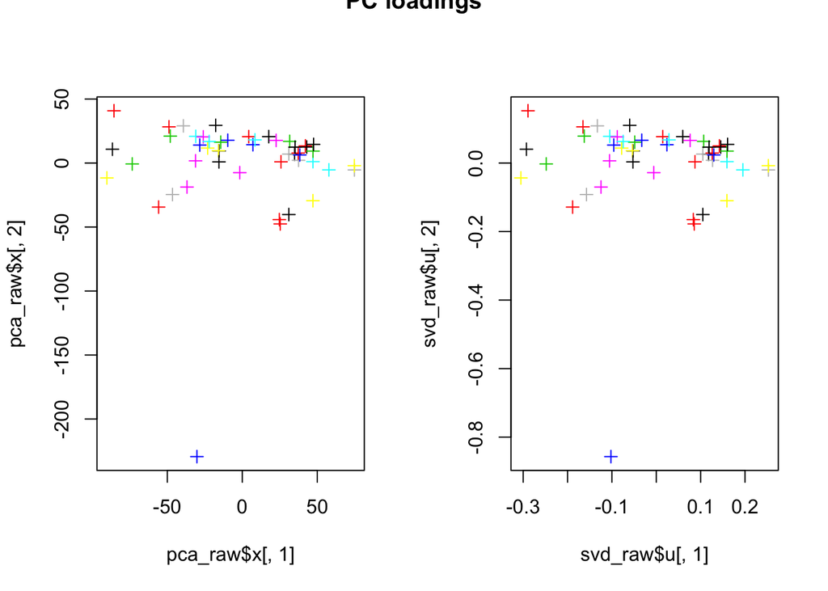

```r
par(mfrow = c(1,2))
plot(pca_raw$x[,1], pca_raw$x[,2], col = 1:10, pch = 3)
plot(svd_raw$u[,1], svd_raw$u[,2], col = 1:10, pch = 3)
title(main = "PC loadings", outer = TRUE)
```

### Percent variance explained

```r
scores_pca_raw <- round( (pca_raw$sdev^2)/sum(pca_raw$sdev^2), 4)
scores_svd_raw <- round( (svd_raw$d^2)/sum(svd_raw$d^2), 4)
cbind(scores_pca_raw, scores_svd_raw)
```

```
##       scores_pca_raw scores_svd_raw
##  [1,]         0.0426         0.0426
##  [2,]         0.0349         0.0349
##  [3,]         0.0289         0.0289
##  [4,]         0.0283         0.0283
##  [5,]         0.0274         0.0274
##  [6,]         0.0268         0.0268
##  [7,]         0.0262         0.0262
##  [8,]         0.0258         0.0258
##  [9,]         0.0256         0.0256
## [10,]         0.0244         0.0244
## [11,]         0.0243         0.0243
## [12,]         0.0241         0.0241
## [13,]         0.0237         0.0237
## [14,]         0.0232         0.0232
```

[output cut: 35 more lines]

### Rotation

```r
pca_raw$rotation[1:3, 1:3]
```

```
##                             PC1          PC2          PC3
## 0610007C21Rik_Apr3 -0.016746421  0.007084973 -0.020568149
## 0610007L01Rik       0.005243759  0.002326192  0.002509946
## 0610007P08Rik       0.002858004 -0.006245783  0.002145578
```

```r
svd_raw$v[1:3, 1:3]
```

```
##              [,1]         [,2]         [,3]
## [1,] -0.016746421  0.007084973 -0.020568149
## [2,]  0.005243759  0.002326192  0.002509946
## [3,]  0.002858004 -0.006245783  0.002145578
```

## Unit variance versus raw variance

Raw variance case

```r
pca_raw <- gmodels::fast.prcomp(jaitin_log2cpm_transpose,
                                retx = TRUE,
                                center = TRUE,
                                scale. = FALSE)
str(pca_raw)
```

```
## List of 3
##  $ sdev    : num [1:49] 42.7 38.6 35.2 34.8 34.2 ...
##  $ rotation: num [1:20190, 1:49] -0.01675 0.00524 0.00286 -0.01119 -0.01536 ...
##   ..- attr(*, "dimnames")=List of 2
##   .. ..$ : chr [1:20190] "0610007C21Rik_Apr3" "0610007L01Rik" "0610007P08Rik" "0610007P14Rik" ...
##   .. ..$ : chr [1:49] "PC1" "PC2" "PC3" "PC4" ...
##  $ x       : num [1:49, 1:49] -15.5 42 31.6 -28.3 47.1 ...
##   ..- attr(*, "dimnames")=List of 2
##   .. ..$ : chr [1:49] "X0_1" "X0_2" "X0_3" "X0_4" ...
##   .. ..$ : chr [1:49] "PC1" "PC2" "PC3" "PC4" ...
##  - attr(*, "class")= chr "prcomp"
```

Unit variance case. Variable sums (column) need to be greater than 0.

```r
jaitin_log2cpm_transpose_filter <-
    jaitin_log2cpm_transpose[ , colSums(jaitin_log2cpm_transpose) != 0]
pca_unit <- gmodels::fast.prcomp(jaitin_log2cpm_transpose_filter,
                                 retx = TRUE,
                                 center = TRUE,
                                 scale. = TRUE)
str(pca_unit)
```

```
## List of 3
##  $ sdev    : num [1:49] 17.3 15.8 15.4 15.2 15 ...
##  $ rotation: num [1:7497, 1:49] 0.00199 0.00323 -0.00133 0.00271 0.00468 ...
##   ..- attr(*, "dimnames")=List of 2
##   .. ..$ : chr [1:7497] "0610007C21Rik_Apr3" "0610007L01Rik" "0610007P08Rik" "0610007P14Rik" ...
##   .. ..$ : chr [1:49] "PC1" "PC2" "PC3" "PC4" ...
##  $ x       : num [1:49, 1:49] 1.56 4.58 4.46 1.96 2.98 ...
##   ..- attr(*, "dimnames")=List of 2
##   .. ..$ : chr [1:49] "X0_1" "X0_2" "X0_3" "X0_4" ...
##   .. ..$ : chr [1:49] "PC1" "PC2" "PC3" "PC4" ...
##  - attr(*, "class")= chr "prcomp"
```

### Principal component loadings

PC coordiantes are different under these scenarios.

```r
cbind(pca_raw$x[ ,1], pca_unit$x[ ,1])
```

```
##             [,1]         [,2]
## X0_1  -15.481894    1.5600201
## X0_2   42.049657    4.5781666
## X0_3   31.614260    4.4590904
## X0_4  -28.341496    1.9589833
## X0_5   47.110127    2.9814828
## X0_6   -1.677101    1.2850287
## X0_7   47.086452   -0.1863229
## X0_8   74.758359    2.7370467
## X0_9   34.861058    4.1677180
## X0_10   4.287097    5.2018810
## X0_11  31.020509   -2.8859927
## X0_12 -85.544838    3.8392868
## X0_13 -14.365362    3.8602691
## X0_14  -9.701574    3.8031541
## X0_15 -31.043546    3.9568183
## X0_16 -31.172554    1.2999915
## X0_17 -15.917660    3.1009372
## X0_18  31.023521    3.3427572
## X0_19 -86.598868    0.5745554
## X0_20  25.800273    1.2540867
## X0_21  17.657580    3.5235992
## X0_22 -48.878657    5.9609999
## X0_23 -73.404002   -1.1087107
## X0_24   7.079304    3.8497134
## X0_25  57.732849    4.1706918
## X0_26 -26.023311    3.0292225
## X0_27 -23.087145    3.8892416
## X0_28  37.507066    1.8851004
## X0_29  42.954169    4.5673069
## X0_30  37.290329    2.2876722
## X0_31 -17.732043    5.0410650
## X0_32  24.698556   -2.7393412
## X0_33 -48.026405    3.5653273
## X0_34 -30.265563 -117.4312026
## X0_35 -22.093789    3.1110954
## X0_36 -36.878833    0.2232833
## X0_37 -90.287859   -0.5655414
## X0_38 -46.550152   -1.9742188
## X0_39  35.179569    4.8545490
## X0_40 -55.803111   -6.4969897
## X0_41 -15.565307    1.0653736
## X0_42  25.283076   -3.7655457
## X0_44  47.165168    4.0694794
## X0_45  38.331346    3.6506759
## X0_46   8.430237    5.5401637
## X0_47  22.572159    5.0745607
## X0_48  74.726010    3.7820934
## X0_49 -39.305559    5.2690901
## X0_50  47.527897    4.7822871
```

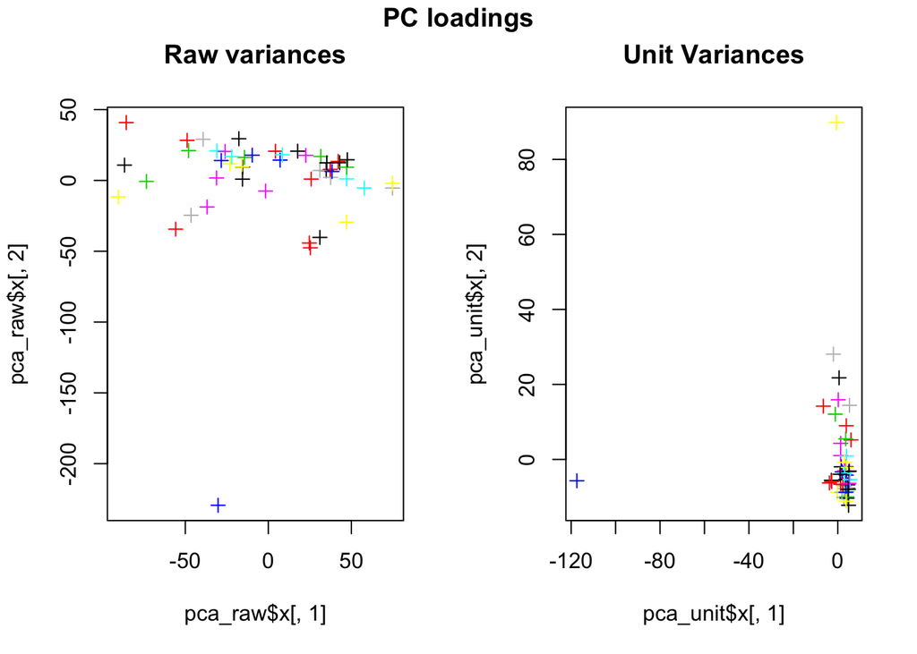

```r
par(mfrow = c(1,2))
plot(pca_raw$x[,1], pca_raw$x[,2], col = 1:10, pch = 3,
     main = "Raw variances")
plot(pca_unit$x[,1], pca_unit$x[,2], col = 1:10, pch = 3,
     main = "Unit Variances")
title(main = "PC loadings", outer = TRUE, line = -1)
```

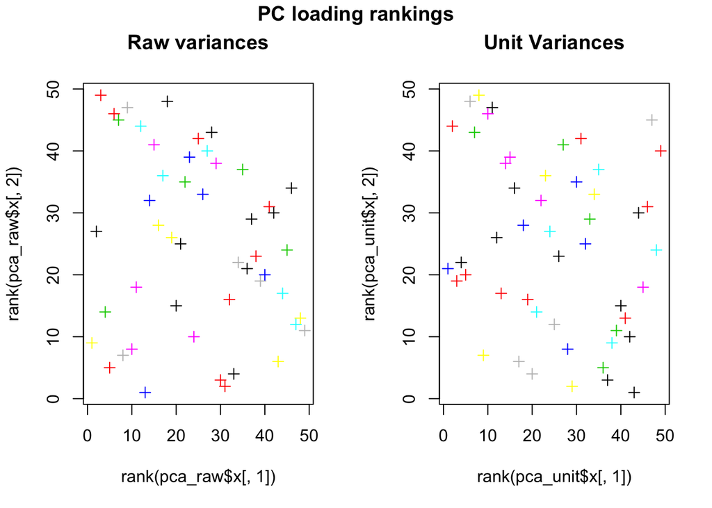

```r
par(mfrow = c(1,2))
plot(rank(pca_raw$x[,1]), rank(pca_raw$x[,2]), col = 1:10, pch = 3,
     main = "Raw variances")
plot(rank(pca_unit$x[,1]), rank(pca_unit$x[,2]), col = 1:10, pch = 3,
     main = "Unit Variances")
title(main = "PC loading rankings", outer = TRUE, line = -1)
```

### Percent variance explained

Percent variance explained by each PC component is not the same after we transform raw variances to unit variances.

```r
scores_pca_raw <- round( (pca_raw$sdev^2)/sum(pca_raw$sdev^2), 4)
scores_pca_unit <- round( (pca_unit$sdev^2)/sum(pca_unit$sdev^2), 4)
cbind(scores_pca_raw, scores_pca_unit)
```

```
##       scores_pca_raw scores_pca_unit
##  [1,]         0.0426          0.0401
##  [2,]         0.0349          0.0332
##  [3,]         0.0289          0.0317
##  [4,]         0.0283          0.0306
##  [5,]         0.0274          0.0300
##  [6,]         0.0268          0.0296
##  [7,]         0.0262          0.0276
##  [8,]         0.0258          0.0266
##  [9,]         0.0256          0.0258
## [10,]         0.0244          0.0257
## [11,]         0.0243          0.0250
## [12,]         0.0241          0.0245
## [13,]         0.0237          0.0238
## [14,]         0.0232          0.0231
```

[output cut: 35 more lines]

### Rotation

Rotation parameters are also different.

```r
round(pca_raw$rotation[1:3, 1:3], 4)
```

```
##                        PC1     PC2     PC3
## 0610007C21Rik_Apr3 -0.0167  0.0071 -0.0206
## 0610007L01Rik       0.0052  0.0023  0.0025
## 0610007P08Rik       0.0029 -0.0062  0.0021
```

```r
round(pca_unit$rotation[1:3, 1:3], 4)
```

```
##                        PC1     PC2     PC3
## 0610007C21Rik_Apr3  0.0020 -0.0003  0.0023
## 0610007L01Rik       0.0032  0.0004 -0.0231
## 0610007P08Rik      -0.0013 -0.0034  0.0017
```